# Logistic Regression Project

Peter

February 28, 2019

GOAL: Predict if people belong in a certain class by salary, either making <=50k or >=50k

# Setup

```r
adult <- read.csv('adult_sal.csv')
head(adult)
```

```
##   X age    type_employer fnlwgt education education_num            marital
## 1 1  39        State-gov  77516 Bachelors            13      Never-married
## 2 2  50 Self-emp-not-inc  83311 Bachelors            13 Married-civ-spouse
## 3 3  38          Private 215646   HS-grad             9           Divorced
## 4 4  53          Private 234721      11th             7 Married-civ-spouse
## 5 5  28          Private 338409 Bachelors            13 Married-civ-spouse
## 6 6  37          Private 284582   Masters            14 Married-civ-spouse
##          occupation  relationship  race    sex capital_gain capital_loss
## 1      Adm-clerical Not-in-family White   Male         2174            0
## 2   Exec-managerial       Husband White   Male            0            0
## 3 Handlers-cleaners Not-in-family White   Male            0            0
## 4 Handlers-cleaners       Husband Black   Male            0            0
## 5    Prof-specialty          Wife Black Female            0            0
## 6   Exec-managerial          Wife White Female            0            0
##   hr_per_week       country income
## 1          40 United-States  <=50K
## 2          13 United-States  <=50K
## 3          40 United-States  <=50K
## 4          40 United-States  <=50K
## 5          40          Cuba  <=50K
## 6          40 United-States  <=50K
```

```r
table(adult$country)
```

```
##
##                          ?                   Cambodia
##                        583                         19
##                     Canada                      China
##                        121                         75
##                   Columbia                       Cuba
##                         59                         95
##         Dominican-Republic                    Ecuador
##                         70                         28
##                El-Salvador                    England
##                        106                         90
##                     France                    Germany
##                         29                        137
##                     Greece                  Guatemala
##                         29                         64
##                      Haiti         Holand-Netherlands
##                         44                          1
##                   Honduras                       Hong
##                         13                         20
##                    Hungary                      India
##                         13                        100
##                       Iran                    Ireland
##                         43                         24
##                      Italy                    Jamaica
##                         73                         81
##                      Japan                       Laos
##                         62                         18
##                     Mexico                  Nicaragua
##                        643                         34
## Outlying-US(Guam-USVI-etc)                       Peru
##                         14                         31
##                Philippines                     Poland
##                        198                         60
##                   Portugal                Puerto-Rico
##                         37                        114
##                   Scotland                      South
##                         12                         80
##                     Taiwan                   Thailand
##                         51                         18
##            Trinadad&Tobago              United-States
##                         19                      29170
##                    Vietnam                 Yugoslavia
##                         67                         16
```

```r
library(dplyr)
adult <- select(adult,-X)
head(adult)
```

```
##   age    type_employer fnlwgt education education_num            marital
## 1  39        State-gov  77516 Bachelors            13      Never-married
## 2  50 Self-emp-not-inc  83311 Bachelors            13 Married-civ-spouse
## 3  38          Private 215646   HS-grad             9           Divorced
## 4  53          Private 234721      11th             7 Married-civ-spouse
## 5  28          Private 338409 Bachelors            13 Married-civ-spouse
## 6  37          Private 284582   Masters            14 Married-civ-spouse
##          occupation  relationship  race    sex capital_gain capital_loss
## 1      Adm-clerical Not-in-family White   Male         2174            0
## 2   Exec-managerial       Husband White   Male            0            0
## 3 Handlers-cleaners Not-in-family White   Male            0            0
## 4 Handlers-cleaners       Husband Black   Male            0            0
## 5    Prof-specialty          Wife Black Female            0            0
## 6   Exec-managerial          Wife White Female            0            0
##   hr_per_week       country income
## 1          40 United-States  <=50K
## 2          13 United-States  <=50K
## 3          40 United-States  <=50K
## 4          40 United-States  <=50K
## 5          40          Cuba  <=50K
## 6          40 United-States  <=50K
```

```r
str(adult)
```

```
## 'data.frame':    32561 obs. of  15 variables:
##  $ age          : int  39 50 38 53 28 37 49 52 31 42 ...
##  $ type_employer: Factor w/ 9 levels "?","Federal-gov",..: 8 7 5 5 5 5 5 7 5 5 ...
##  $ fnlwgt       : int  77516 83311 215646 234721 338409 284582 160187 209642 45781 159449 ...
##  $ education    : Factor w/ 16 levels "10th","11th",..: 10 10 12 2 10 13 7 12 13 10 ...
##  $ education_num: int  13 13 9 7 13 14 5 9 14 13 ...
##  $ marital      : Factor w/ 7 levels "Divorced","Married-AF-spouse",..: 5 3 1 3 3 3 4 3 5 3 ...
##  $ occupation   : Factor w/ 15 levels "?","Adm-clerical",..: 2 5 7 7 11 5 9 5 11 5 ...
##  $ relationship : Factor w/ 6 levels "Husband","Not-in-family",..: 2 1 2 1 6 6 2 1 2 1 ...
##  $ race         : Factor w/ 5 levels "Amer-Indian-Eskimo",..: 5 5 5 3 3 5 3 5 5 5 ...
##  $ sex          : Factor w/ 2 levels "Female","Male": 2 2 2 2 1 1 1 2 1 2 ...
##  $ capital_gain : int  2174 0 0 0 0 0 0 0 14084 5178 ...
##  $ capital_loss : int  0 0 0 0 0 0 0 0 0 0 ...
##  $ hr_per_week  : int  40 13 40 40 40 40 16 45 50 40 ...
##  $ country      : Factor w/ 42 levels "?","Cambodia",..: 40 40 40 40 6 40 24 40 40 40 ...
##  $ income       : Factor w/ 2 levels "<=50K",">50K": 1 1 1 1 1 1 1 2 2 2 ...
```

```r
summary(adult)
```

```
##       age                 type_employer       fnlwgt
##  Min.   :17.00   Private         :22696   Min.   :  12285
##  1st Qu.:28.00   Self-emp-not-inc: 2541   1st Qu.: 117827
##  Median :37.00   Local-gov       : 2093   Median : 178356
##  Mean   :38.58   ?               : 1836   Mean   : 189778
##  3rd Qu.:48.00   State-gov       : 1298   3rd Qu.: 237051
##  Max.   :90.00   Self-emp-inc    : 1116   Max.   :1484705
##                  (Other)         :  981
##         education     education_num                    marital
##  HS-grad     :10501   Min.   : 1.00   Divorced             : 4443
##  Some-college: 7291   1st Qu.: 9.00   Married-AF-spouse    :   23
##  Bachelors   : 5355   Median :10.00   Married-civ-spouse   :14976
##  Masters     : 1723   Mean   :10.08   Married-spouse-absent:  418
##  Assoc-voc   : 1382   3rd Qu.:12.00   Never-married        :10683
##  11th        : 1175   Max.   :16.00   Separated            : 1025
##  (Other)     : 5134                   Widowed              :  993
##            occupation           relationship                   race
##  Prof-specialty :4140   Husband       :13193   Amer-Indian-Eskimo:  311
##  Craft-repair   :4099   Not-in-family : 8305   Asian-Pac-Islander: 1039
##  Exec-managerial:4066   Other-relative:  981   Black             : 3124
##  Adm-clerical   :3770   Own-child     : 5068   Other             :  271
##  Sales          :3650   Unmarried     : 3446   White             :27816
##  Other-service  :3295   Wife          : 1568
##  (Other)        :9541
##      sex         capital_gain    capital_loss     hr_per_week
##  Female:10771   Min.   :    0   Min.   :   0.0   Min.   : 1.00
##  Male  :21790   1st Qu.:    0   1st Qu.:   0.0   1st Qu.:40.00
##                 Median :    0   Median :   0.0   Median :40.00
##                 Mean   : 1078   Mean   :  87.3   Mean   :40.44
##                 3rd Qu.:    0   3rd Qu.:   0.0   3rd Qu.:45.00
##                 Max.   :99999   Max.   :4356.0   Max.   :99.00
##
##           country        income
##  United-States:29170   <=50K:24720
##  Mexico       :  643   >50K : 7841
##  ?            :  583
##  Philippines  :  198
##  Germany      :  137
##  Canada       :  121
##  (Other)      : 1709
```

# Data Cleaning

```r
table(adult$type_employer)
```

```
##
##                ?      Federal-gov        Local-gov     Never-worked
##             1836              960             2093                7
##          Private     Self-emp-inc Self-emp-not-inc        State-gov
##            22696             1116             2541             1298
##      Without-pay
##               14
```

- There are 1836 null values, the smallest group is the ‘never-worked’ group

## Combine ‘Never-worked’ and ‘Without-pay’ into ‘Unemployed’

```r
  unemp <- function(x){
      x <- as.character(x)
      if (x == 'Never-worked' | x=='Without-pay'){
        return('Unemployed')
      }else{
        return(x)
      }
    }

  adult$type_employer <- sapply(adult$type_employer, unemp)
  adult$type_employer <- factor(adult$type_employer)
```

## Combine ‘State-gov’ and ‘Local-gov’ into ‘SL-gov’

```r
  gov <- function(x){
    x <- as.character(x)
    if (x=='State-gov' | x=='Local-gov'){
      return('SL-gov')
    }else{
      return(x)
    }
  }
  adult$type_employer <- sapply(adult$type_employer, gov)
  table(adult$type_employer)
```

```
##
##                ?      Federal-gov          Private     Self-emp-inc
##             1836              960            22696             1116
## Self-emp-not-inc           SL-gov       Unemployed
##             2541             3391               21
```

## Combine ‘Self-emp-inc’ and ‘Self-emp-not-inc’ into ‘Self-emp’

```r
  self <- function(x){
    x <- as.character(x)
    if (x=='Self-emp-inc' | x=='Self-emp-not-inc'){
      return('Self-emp')
    }else{
      return(x)
    }
  }
  adult$type_employer <- sapply(adult$type_employer, self)
  table(adult$type_employer)
```

```
##
##           ? Federal-gov     Private    Self-emp      SL-gov  Unemployed
##        1836         960       22696        3657        3391          21
```

## Reduce Marital column to ‘Married’, ‘Not-Married’, ‘Never-Married’

```r
  table(adult$marital)
```

```
##
##              Divorced     Married-AF-spouse    Married-civ-spouse
##                  4443                    23                 14976
## Married-spouse-absent         Never-married             Separated
##                   418                 10683                  1025
##               Widowed
##                   993
```

```r
  SO <- function(x){
    x <- as.character(x)
    if (x=='Married-spouse-absent' | x=='Married-AF-spouse' | x=='Married-civ-spouse'){
      return('Married')
    }else if (x=='Divorced' | x=='Separated' | x=='Widowed'){
      return('Not Married')
    }else{
      return('Never Married')
    }
  }
  adult$marital <- sapply(adult$marital, SO)
  adult$marital <- factor(adult$marital)
```

## Group the countries column

```r
  continents <- function(x){
    x <- as.character(x)
    if(x=='France'|x=='Holand-Netherlands'|x=='Germany'|x=='Cambodia'|x=='Ireland'
       |x=='Poland'|x=='Yugoslavia'|x=='Portugal'|x=='Greece'|x=='Italy'|x=='Hungary'|x=='England'|x=='Scotland'){
      return('Europe')
    }else if(x=='Vietnam'|x=='Philippines'|x=='Iran'|x=='Hong'|x=='South'|x=='Philippenes'|x=='Taiwan'|x=='Thailand'|x=='China'|x=='India'|x=='Japan'|x=='Laos'){
      return('Asia')
    }else if(x=='El Salvador'|x=='Guatemala'|x=='Jamaica'
             |x=='Outlying-US(Guam-USVI-etc)'|x=='Trinadad&Tobago'|x=='Mexico'
             |x=='Honduras'|x=='Nicaragua'|x=='Cuba'){
      return('Central America')
    }else if(x=='Columbia'|x=='Ecuador'|x=='Peru'|x=='Dominican-Republic'){
      return('South America')
    }else if(x=='Puerto-Rico'|x=='United-States'|x=='Canada'|x=='Haiti'|x=='El-Salvador'){
      return('North America')
    }else{
      return(x)
    }
  }
  adult$country <- sapply(adult$country,continents)
  adult$country <- factor(adult$country)
  table(adult$country)
```

```
##
##               ?            Asia Central America          Europe
##             583             732             963             540
##   North America   South America
##           29555             188
```

```r
str(adult)
```

```
## 'data.frame':    32561 obs. of  15 variables:
##  $ age          : int  39 50 38 53 28 37 49 52 31 42 ...
##  $ type_employer: chr  "SL-gov" "Self-emp" "Private" "Private" ...
##  $ fnlwgt       : int  77516 83311 215646 234721 338409 284582 160187 209642 45781 159449 ...
##  $ education    : Factor w/ 16 levels "10th","11th",..: 10 10 12 2 10 13 7 12 13 10 ...
##  $ education_num: int  13 13 9 7 13 14 5 9 14 13 ...
##  $ marital      : Factor w/ 3 levels "Married","Never Married",..: 2 1 3 1 1 1 1 1 2 1 ...
##  $ occupation   : Factor w/ 15 levels "?","Adm-clerical",..: 2 5 7 7 11 5 9 5 11 5 ...
##  $ relationship : Factor w/ 6 levels "Husband","Not-in-family",..: 2 1 2 1 6 6 2 1 2 1 ...
##  $ race         : Factor w/ 5 levels "Amer-Indian-Eskimo",..: 5 5 5 3 3 5 3 5 5 5 ...
##  $ sex          : Factor w/ 2 levels "Female","Male": 2 2 2 2 1 1 1 2 1 2 ...
##  $ capital_gain : int  2174 0 0 0 0 0 0 0 14084 5178 ...
##  $ capital_loss : int  0 0 0 0 0 0 0 0 0 0 ...
##  $ hr_per_week  : int  40 13 40 40 40 40 16 45 50 40 ...
##  $ country      : Factor w/ 6 levels "?","Asia","Central America",..: 5 5 5 5 3 5 3 5 5 5 ...
##  $ income       : Factor w/ 2 levels "<=50K",">50K": 1 1 1 1 1 1 1 2 2 2 ...
```

- Could have also created a list of countries (continent <- c(ctry,ctry,ctry)) and then check if the cell string is in the continent list.
- if x in continent, return ‘continent.’

# Missing Data

```r
library(Amelia)
```

## Convert ? to NA

```r
adult[adult == '?'] <- NA # Cheated
```

## Refactor data

```r
adult$education <- factor(adult$education)
adult$marital <- factor(adult$marital)
adult$occupation <- factor(adult$occupation)
adult$relationship <- factor(adult$relationship)
adult$race <- factor(adult$race)
adult$sex <- factor(adult$sex)
adult$country <- factor(adult$country)
```

## Check for NaNs using missmap

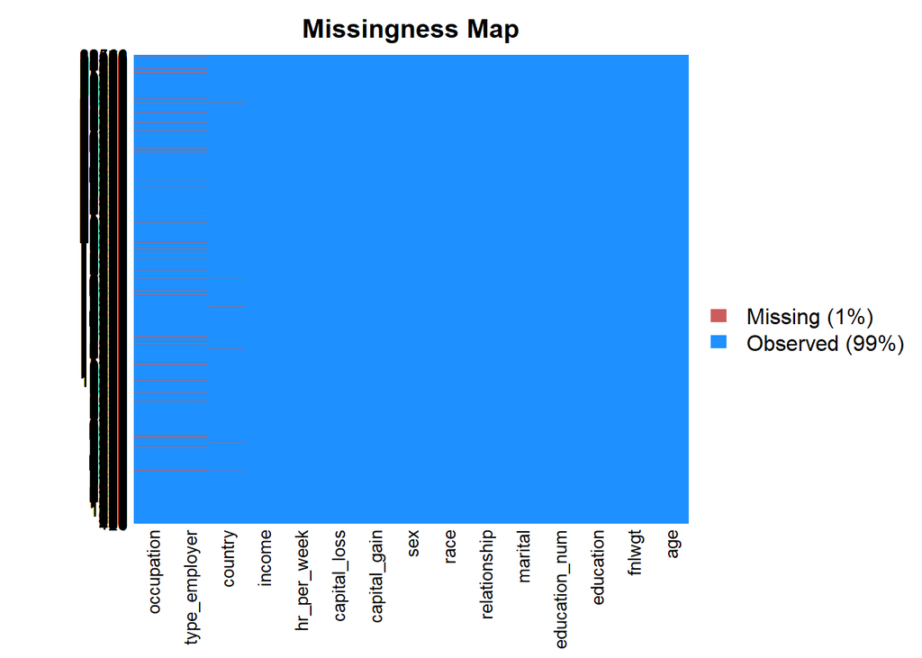

```r
missmap(adult)
```

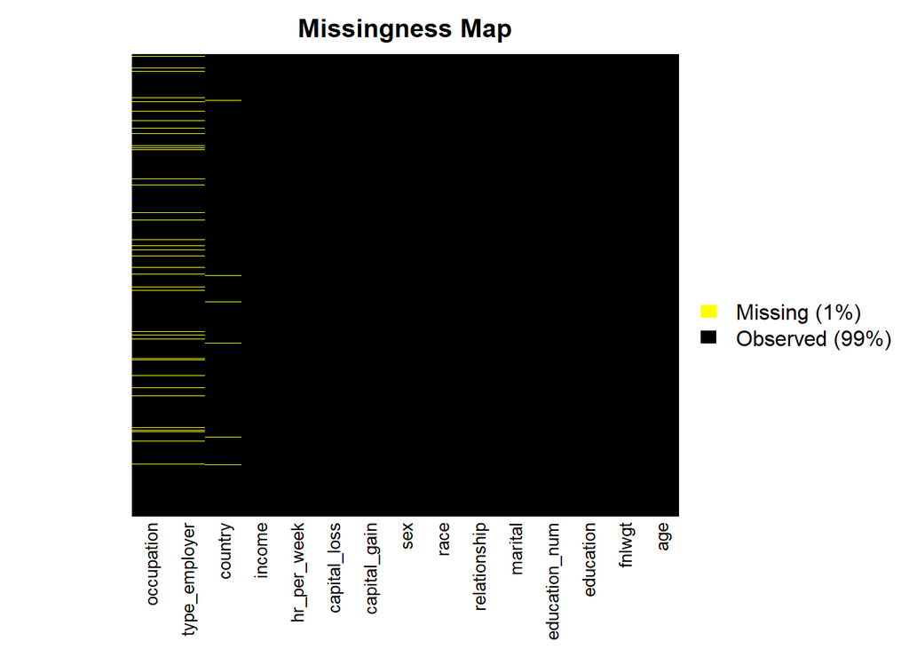

```r
missmap(adult,y.at=c(1),y.labels = c(''),col=c('yellow','black'))
```

- Sample args. yellow = missing, black = observed.

## Get rid of NaNs

```r
adult <- na.omit(adult)
str(adult)
```

```
## 'data.frame':    30162 obs. of  15 variables:
##  $ age          : int  39 50 38 53 28 37 49 52 31 42 ...
##  $ type_employer: chr  "SL-gov" "Self-emp" "Private" "Private" ...
##  $ fnlwgt       : int  77516 83311 215646 234721 338409 284582 160187 209642 45781 159449 ...
##  $ education    : Factor w/ 16 levels "10th","11th",..: 10 10 12 2 10 13 7 12 13 10 ...
##  $ education_num: int  13 13 9 7 13 14 5 9 14 13 ...
##  $ marital      : Factor w/ 3 levels "Married","Never Married",..: 2 1 3 1 1 1 1 1 2 1 ...
##  $ occupation   : Factor w/ 14 levels "Adm-clerical",..: 1 4 6 6 10 4 8 4 10 4 ...
##  $ relationship : Factor w/ 6 levels "Husband","Not-in-family",..: 2 1 2 1 6 6 2 1 2 1 ...
##  $ race         : Factor w/ 5 levels "Amer-Indian-Eskimo",..: 5 5 5 3 3 5 3 5 5 5 ...
##  $ sex          : Factor w/ 2 levels "Female","Male": 2 2 2 2 1 1 1 2 1 2 ...
##  $ capital_gain : int  2174 0 0 0 0 0 0 0 14084 5178 ...
##  $ capital_loss : int  0 0 0 0 0 0 0 0 0 0 ...
##  $ hr_per_week  : int  40 13 40 40 40 40 16 45 50 40 ...
##  $ country      : Factor w/ 5 levels "Asia","Central America",..: 4 4 4 4 2 4 2 4 4 4 ...
##  $ income       : Factor w/ 2 levels "<=50K",">50K": 1 1 1 1 1 1 1 2 2 2 ...
##  - attr(*, "na.action")= 'omit' Named int  15 28 39 52 62 70 78 94 107 129 ...
##   ..- attr(*, "names")= chr  "15" "28" "39" "52" ...
```

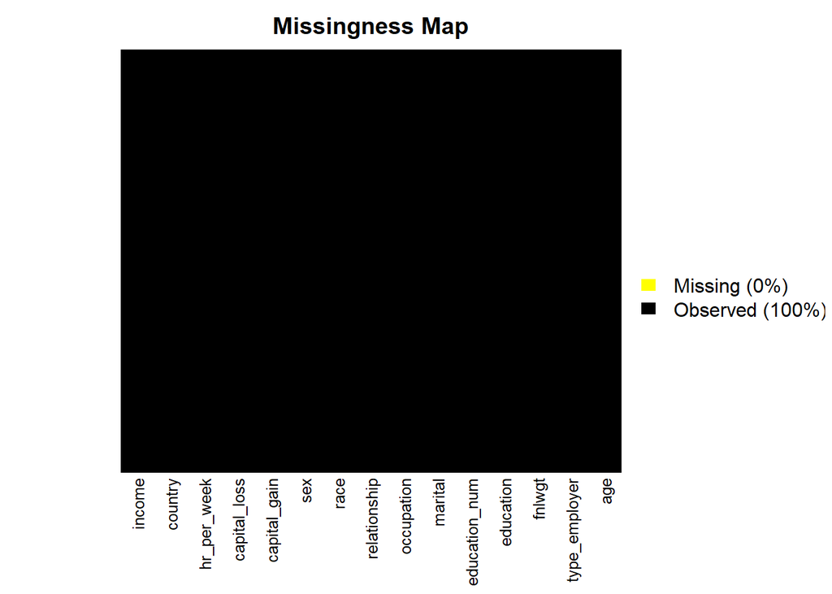

```r
missmap(adult,y.at=c(1),y.labels = c(''),col=c('yellow','black'))
```

# Exploratory Data Analysis

```r
str(adult)
```

```
## 'data.frame':    30162 obs. of  15 variables:
##  $ age          : int  39 50 38 53 28 37 49 52 31 42 ...
##  $ type_employer: chr  "SL-gov" "Self-emp" "Private" "Private" ...
##  $ fnlwgt       : int  77516 83311 215646 234721 338409 284582 160187 209642 45781 159449 ...
##  $ education    : Factor w/ 16 levels "10th","11th",..: 10 10 12 2 10 13 7 12 13 10 ...
##  $ education_num: int  13 13 9 7 13 14 5 9 14 13 ...
##  $ marital      : Factor w/ 3 levels "Married","Never Married",..: 2 1 3 1 1 1 1 1 2 1 ...
##  $ occupation   : Factor w/ 14 levels "Adm-clerical",..: 1 4 6 6 10 4 8 4 10 4 ...
##  $ relationship : Factor w/ 6 levels "Husband","Not-in-family",..: 2 1 2 1 6 6 2 1 2 1 ...
##  $ race         : Factor w/ 5 levels "Amer-Indian-Eskimo",..: 5 5 5 3 3 5 3 5 5 5 ...
##  $ sex          : Factor w/ 2 levels "Female","Male": 2 2 2 2 1 1 1 2 1 2 ...
##  $ capital_gain : int  2174 0 0 0 0 0 0 0 14084 5178 ...
##  $ capital_loss : int  0 0 0 0 0 0 0 0 0 0 ...
##  $ hr_per_week  : int  40 13 40 40 40 40 16 45 50 40 ...
##  $ country      : Factor w/ 5 levels "Asia","Central America",..: 4 4 4 4 2 4 2 4 4 4 ...
##  $ income       : Factor w/ 2 levels "<=50K",">50K": 1 1 1 1 1 1 1 2 2 2 ...
##  - attr(*, "na.action")= 'omit' Named int  15 28 39 52 62 70 78 94 107 129 ...
##   ..- attr(*, "names")= chr  "15" "28" "39" "52" ...
```

```r
library(ggplot2)
```

## Histogram of ages, by income

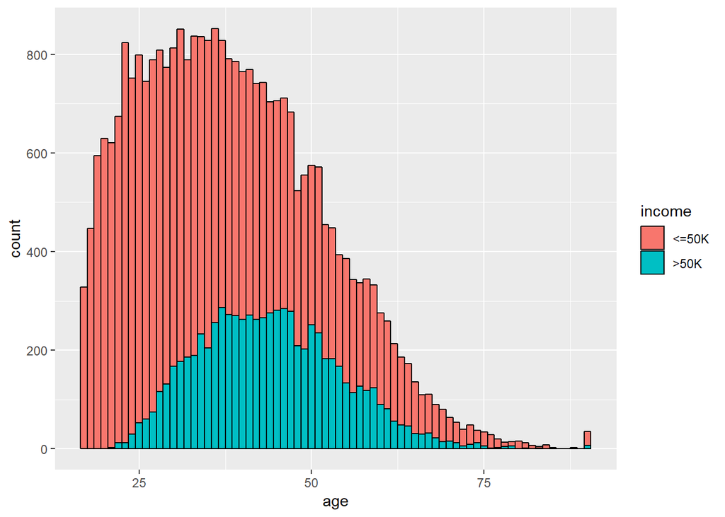

```r
pl <- ggplot(data=adult,aes(age))
pl + geom_histogram(aes(fill=income),color='black',binwidth = 1)
```

## Histogram of hours worked/week

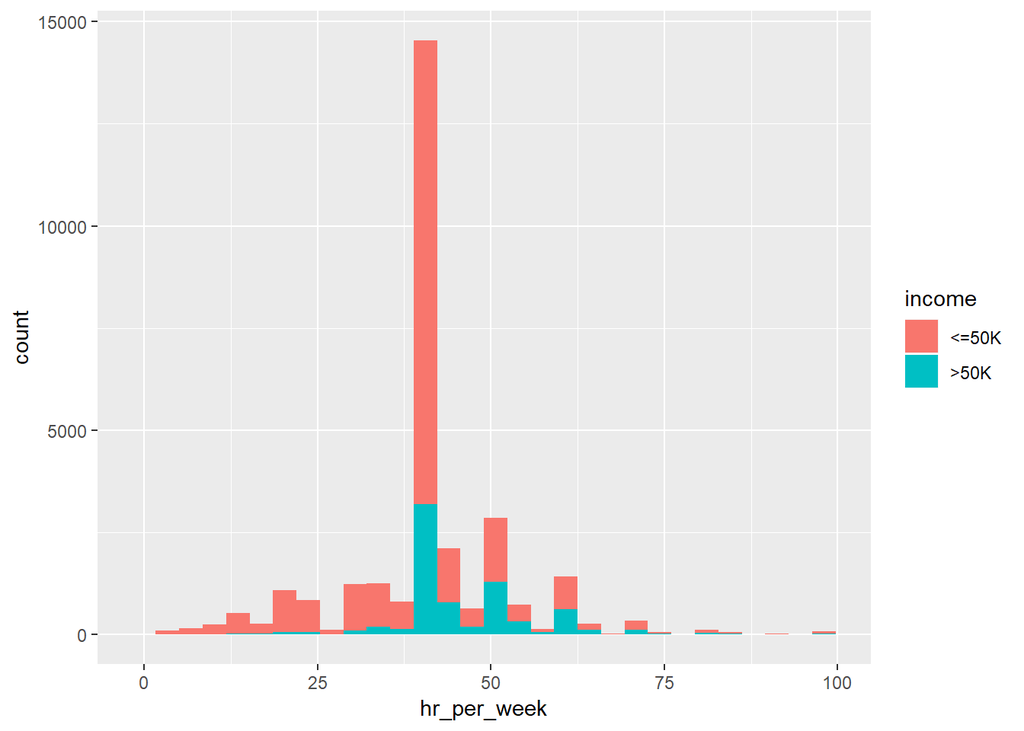

```r
pl2 <- ggplot(data=adult,aes(hr_per_week))
pl2 + geom_histogram(aes(fill=income))
```

## Rename country column

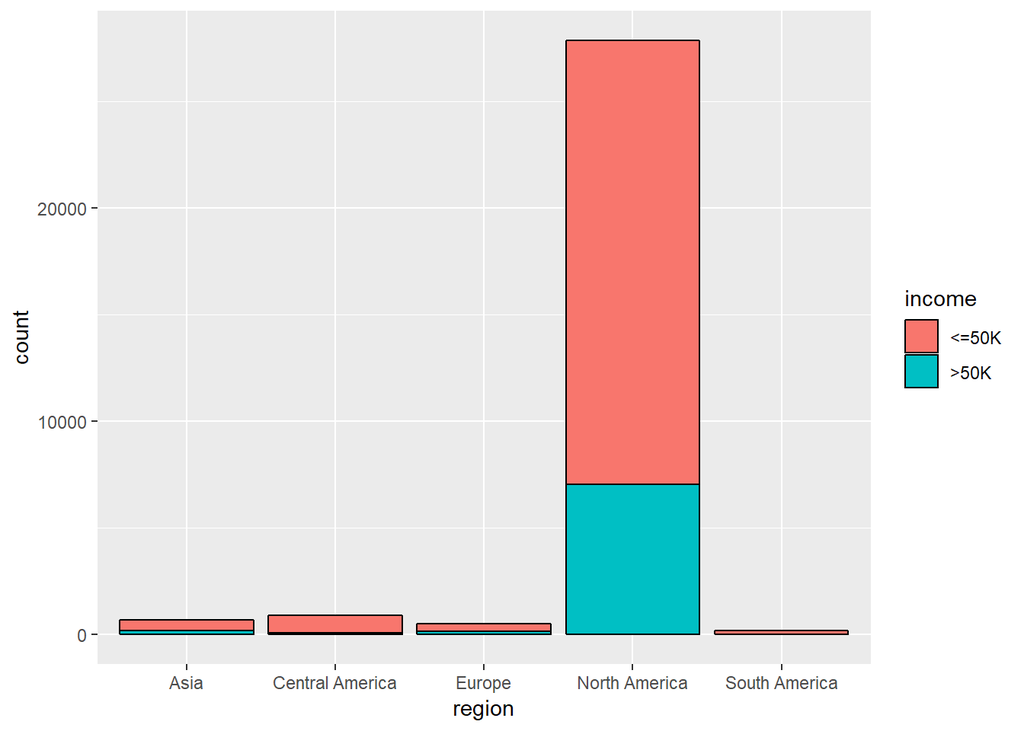

```r
adult$region <- adult$country
adult <- select(adult,-country) # remove the country column using dplyr
pl3 <- ggplot(data=adult,aes(region))
pl3 + geom_bar(aes(fill=income),color='black')
```

- Can also use dplyr: adult <- rename(adult,region = country)

# Build a Model

## Split the data

```r
head(adult)
```

```
##   age type_employer fnlwgt education education_num       marital
## 1  39        SL-gov  77516 Bachelors            13 Never Married
## 2  50      Self-emp  83311 Bachelors            13       Married
## 3  38       Private 215646   HS-grad             9   Not Married
## 4  53       Private 234721      11th             7       Married
## 5  28       Private 338409 Bachelors            13       Married
## 6  37       Private 284582   Masters            14       Married
##          occupation  relationship  race    sex capital_gain capital_loss
## 1      Adm-clerical Not-in-family White   Male         2174            0
## 2   Exec-managerial       Husband White   Male            0            0
## 3 Handlers-cleaners Not-in-family White   Male            0            0
## 4 Handlers-cleaners       Husband Black   Male            0            0
## 5    Prof-specialty          Wife Black Female            0            0
## 6   Exec-managerial          Wife White Female            0            0
##   hr_per_week income          region
## 1          40  <=50K   North America
## 2          13  <=50K   North America
## 3          40  <=50K   North America
## 4          40  <=50K   North America
## 5          40  <=50K Central America
## 6          40  <=50K   North America
```

```r
library(caTools)
set.seed(101)
split <- sample.split(adult$income,SplitRatio=0.7)  # 70% will be TRUE
ad.train <- subset(adult,split==T)
ad.test <- subset(adult,split==F)

str(ad.train)
```

```
## 'data.frame':    21114 obs. of  15 variables:
##  $ age          : int  39 50 53 28 37 49 52 42 30 23 ...
##  $ type_employer: chr  "SL-gov" "Self-emp" "Private" "Private" ...
##  $ fnlwgt       : int  77516 83311 234721 338409 284582 160187 209642 159449 141297 122272 ...
##  $ education    : Factor w/ 16 levels "10th","11th",..: 10 10 2 10 13 7 12 10 10 10 ...
##  $ education_num: int  13 13 7 13 14 5 9 13 13 13 ...
##  $ marital      : Factor w/ 3 levels "Married","Never Married",..: 2 1 1 1 1 1 1 1 1 2 ...
##  $ occupation   : Factor w/ 14 levels "Adm-clerical",..: 1 4 6 10 4 8 4 4 10 1 ...
##  $ relationship : Factor w/ 6 levels "Husband","Not-in-family",..: 2 1 1 6 6 2 1 1 1 4 ...
##  $ race         : Factor w/ 5 levels "Amer-Indian-Eskimo",..: 5 5 3 3 5 3 5 5 2 5 ...
##  $ sex          : Factor w/ 2 levels "Female","Male": 2 2 2 1 1 1 2 2 2 1 ...
##  $ capital_gain : int  2174 0 0 0 0 0 0 5178 0 0 ...
##  $ capital_loss : int  0 0 0 0 0 0 0 0 0 0 ...
##  $ hr_per_week  : int  40 13 40 40 40 16 45 40 40 30 ...
##  $ income       : Factor w/ 2 levels "<=50K",">50K": 1 1 1 1 1 1 2 2 2 1 ...
##  $ region       : Factor w/ 5 levels "Asia","Central America",..: 4 4 4 2 4 2 4 4 1 4 ...
```

```r
# ?glm

adult.logit <- glm(income~.,family=binomial(logit),data=ad.train)
```

```
## Warning: glm.fit: fitted probabilities numerically 0 or 1 occurred
```

```r
summary(adult.logit)
```

```
##
## Call:
## glm(formula = income ~ ., family = binomial(logit), data = ad.train)
##
## Deviance Residuals:
##     Min       1Q   Median       3Q      Max
## -5.0697  -0.5202  -0.1919   0.0000   3.6194
##
## Coefficients: (1 not defined because of singularities)
##                               Estimate Std. Error z value Pr(>|z|)
## (Intercept)                 -5.786e+00  4.374e-01 -13.227  < 2e-16 ***
## age                          2.671e-02  2.011e-03  13.283  < 2e-16 ***
## type_employerPrivate        -4.916e-01  1.114e-01  -4.415 1.01e-05 ***
## type_employerSelf-emp       -8.091e-01  1.240e-01  -6.522 6.92e-11 ***
## type_employerSL-gov         -7.611e-01  1.262e-01  -6.032 1.62e-09 ***
## type_employerUnemployed     -1.401e+01  3.753e+02  -0.037 0.970226
## fnlwgt                       8.046e-07  2.094e-07   3.842 0.000122 ***
## education11th                9.454e-03  2.521e-01   0.038 0.970084
## education12th                4.404e-01  3.165e-01   1.391 0.164078
## education1st-4th            -5.358e-01  6.112e-01  -0.877 0.380628
## education5th-6th            -4.100e-01  4.150e-01  -0.988 0.323208
## education7th-8th            -5.017e-01  2.892e-01  -1.735 0.082790 .
## education9th                -3.650e-01  3.394e-01  -1.076 0.282127
## educationAssoc-acdm          1.168e+00  2.134e-01   5.475 4.38e-08 ***
## educationAssoc-voc           1.199e+00  2.040e-01   5.880 4.11e-09 ***
## educationBachelors           1.873e+00  1.894e-01   9.889  < 2e-16 ***
## educationDoctorate           2.719e+00  2.626e-01  10.355  < 2e-16 ***
## educationHS-grad             6.902e-01  1.841e-01   3.750 0.000177 ***
## educationMasters             2.212e+00  2.029e-01  10.904  < 2e-16 ***
## educationPreschool          -1.890e+01  1.634e+02  -0.116 0.907942
## educationProf-school         2.768e+00  2.470e-01  11.205  < 2e-16 ***
## educationSome-college        1.075e+00  1.868e-01   5.754 8.73e-09 ***
## education_num                       NA         NA      NA       NA
## maritalNever Married        -1.497e+00  1.974e-01  -7.583 3.37e-14 ***
## maritalNot Married          -9.037e-01  1.964e-01  -4.602 4.18e-06 ***
## occupationArmed-Forces      -6.380e-01  1.840e+00  -0.347 0.728785
## occupationCraft-repair       1.182e-01  9.635e-02   1.227 0.219789
## occupationExec-managerial    9.058e-01  9.275e-02   9.767  < 2e-16 ***
## occupationFarming-fishing   -1.036e+00  1.716e-01  -6.038 1.56e-09 ***
## occupationHandlers-cleaners -7.179e-01  1.744e-01  -4.118 3.83e-05 ***
```

[output cut: 20 more lines]

```
## hr_per_week                  3.000e-02  2.007e-03  14.943  < 2e-16 ***
## regionCentral America        8.283e-02  2.827e-01   0.293 0.769514
## regionEurope                 8.669e-01  2.592e-01   3.344 0.000825 ***
## regionNorth America          7.116e-01  2.162e-01   3.291 0.000997 ***
## regionSouth America         -1.044e+00  5.538e-01  -1.886 0.059356 .
## ---
## Signif. codes:  0 '***' 0.001 '**' 0.01 '*' 0.05 '.' 0.1 ' ' 1
##
## (Dispersion parameter for binomial family taken to be 1)
##
##     Null deviance: 23697  on 21113  degrees of freedom
## Residual deviance: 13732  on 21060  degrees of freedom
## AIC: 13840
##
## Number of Fisher Scoring iterations: 14
```

- Warning message says that model predicts data either 0 or 100% chance occurring in one of two categories

## Refine the model

### ?step

Compares different logistic models. Tries a bunch of different combinations of variables in logistic regression model, keeps the ones that are significant.

- Uses akaike information criterion to remove predictors not relevant to the model
- AIC estimates the relative amount of information lost by a given model: the less information a model loses, the higher the quality of that model.
- In estimating the amount of information lost by a model, AIC deals with the trade-off between the goodness of fit of the model and the simplicity of the model. In other words, AIC deals with both the risk of overfitting and the risk of underfitting.
- The smaller the AIC the better the model
- AIC only tells the qualitive of a model relative to other models
- Note that AIC tells nothing about the absolute quality of a model, only the quality relative to other models. Thus, if all the candidate models fit poorly, AIC will not give any warning of that. Hence, after selecting a model via AIC, it is usually good practice to validate the absolute quality of the model. Such validation commonly includes checks of the model’s residuals (to determine whether the residuals seem like random) and tests of the model’s predictions. For more on this topic, see statistical model validation.
- Source: [Wikipedia](https://en.wikipedia.org/wiki/Akaike_information_criterion)

```r
new.model <- step(adult.logit)
```

```
## Start:  AIC=13840.4
## income ~ age + type_employer + fnlwgt + education + education_num +
##     marital + occupation + relationship + race + sex + capital_gain +
##     capital_loss + hr_per_week + region
```

[output not shown]

```
##
## Step:  AIC=13840.4
## income ~ age + type_employer + fnlwgt + education + marital +
##     occupation + relationship + race + sex + capital_gain + capital_loss +
##     hr_per_week + region
```

```
##                 Df Deviance   AIC
## <none>                13732 13840
## - race           4    13743 13843
## - fnlwgt         1    13747 13853
## - region         4    13773 13873
## - type_employer  4    13796 13896
## - marital        2    13801 13905
## - sex            1    13808 13914
## - age            1    13910 14016
## - capital_loss   1    13935 14041
## - relationship   5    13968 14066
## - hr_per_week    1    13962 14068
## - occupation    13    14172 14254
## - education     15    14428 14506
## - capital_gain   1    14890 14996
```

```r
summary(new.model)
```

```
##
## Call:
## glm(formula = income ~ age + type_employer + fnlwgt + education +
##     marital + occupation + relationship + race + sex + capital_gain +
##     capital_loss + hr_per_week + region, family = binomial(logit),
##     data = ad.train)
##
## Deviance Residuals:
##     Min       1Q   Median       3Q      Max
## -5.0697  -0.5202  -0.1919   0.0000   3.6194
##
## Coefficients:
##                               Estimate Std. Error z value Pr(>|z|)
## (Intercept)                 -5.786e+00  4.374e-01 -13.227  < 2e-16 ***
## age                          2.671e-02  2.011e-03  13.283  < 2e-16 ***
## type_employerPrivate        -4.916e-01  1.114e-01  -4.415 1.01e-05 ***
## type_employerSelf-emp       -8.091e-01  1.240e-01  -6.522 6.92e-11 ***
## type_employerSL-gov         -7.611e-01  1.262e-01  -6.032 1.62e-09 ***
## type_employerUnemployed     -1.401e+01  3.753e+02  -0.037 0.970226
## fnlwgt                       8.046e-07  2.094e-07   3.842 0.000122 ***
## education11th                9.454e-03  2.521e-01   0.038 0.970084
## education12th                4.404e-01  3.165e-01   1.391 0.164078
## education1st-4th            -5.358e-01  6.112e-01  -0.877 0.380628
## education5th-6th            -4.100e-01  4.150e-01  -0.988 0.323208
## education7th-8th            -5.017e-01  2.892e-01  -1.735 0.082790 .
## education9th                -3.650e-01  3.394e-01  -1.076 0.282127
## educationAssoc-acdm          1.168e+00  2.134e-01   5.475 4.38e-08 ***
## educationAssoc-voc           1.199e+00  2.040e-01   5.880 4.11e-09 ***
## educationBachelors           1.873e+00  1.894e-01   9.889  < 2e-16 ***
## educationDoctorate           2.719e+00  2.626e-01  10.355  < 2e-16 ***
## educationHS-grad             6.902e-01  1.841e-01   3.750 0.000177 ***
## educationMasters             2.212e+00  2.029e-01  10.904  < 2e-16 ***
## educationPreschool          -1.890e+01  1.634e+02  -0.116 0.907942
## educationProf-school         2.768e+00  2.470e-01  11.205  < 2e-16 ***
## educationSome-college        1.075e+00  1.868e-01   5.754 8.73e-09 ***
## maritalNever Married        -1.497e+00  1.974e-01  -7.583 3.37e-14 ***
## maritalNot Married          -9.037e-01  1.964e-01  -4.602 4.18e-06 ***
## occupationArmed-Forces      -6.380e-01  1.840e+00  -0.347 0.728785
## occupationCraft-repair       1.182e-01  9.635e-02   1.227 0.219789
## occupationExec-managerial    9.058e-01  9.275e-02   9.767  < 2e-16 ***
```

[output cut: 22 more lines]

```
## hr_per_week                  3.000e-02  2.007e-03  14.943  < 2e-16 ***
## regionCentral America        8.283e-02  2.827e-01   0.293 0.769514
## regionEurope                 8.669e-01  2.592e-01   3.344 0.000825 ***
## regionNorth America          7.116e-01  2.162e-01   3.291 0.000997 ***
## regionSouth America         -1.044e+00  5.538e-01  -1.886 0.059356 .
## ---
## Signif. codes:  0 '***' 0.001 '**' 0.01 '*' 0.05 '.' 0.1 ' ' 1
##
## (Dispersion parameter for binomial family taken to be 1)
##
##     Null deviance: 23697  on 21113  degrees of freedom
## Residual deviance: 13732  on 21060  degrees of freedom
## AIC: 13840
##
## Number of Fisher Scoring iterations: 14
```

## Analyze the model

### Create a Confusion Matrix

```r
fitted.probabilities <- predict(new.model,newdata=ad.test, type='response')
table(ad.test$income, fitted.probabilities > 0.5)
```

```
##
##         FALSE TRUE
##   <=50K  6282  514
##   >50K    903 1349
```

**Cheated below this, looked up answers**

### Check the performance of the model

#### Accuracy

```r
  fitted.results <- ifelse(fitted.probabilities > 0.5, 1, 0)
  misClasificError <- mean(fitted.results != ad.test)
  print(paste('Accuracy was: ', misClasificError))
```

[output not shown]

```r
  # Answer:
  (6282+1349)/(6282+902+514+1349)
```

```
## [1] 0.843484
```

- Randomly putting observations into the two categories would have given us 50% accuracy
- Our model gave us 84% accuracy.
- Our model correctly predicted the classification of people’s income based on various other variables 84% of the time.

#### Recall:

How many relevant items are selected?

```r
  (6282)/(6282+514)
```

```
## [1] 0.9243673
```

#### Precision:

How many selected items are relevant?

```r
  (6282)/(6282+903)
```

```
## [1] 0.8743215
```

# Conclusion:

Since we don’t know what it will be used for, we can’t say whether this is a good model or not.